# Gold Export Trends and Opportunities in African Markets

### Analysis for South Africa and Kenya

```r
ydf <- read.csv('../data/yearly_cleaned_export.csv')
ydf$date <- lubridate::ymd(ydf$date, truncated = 2L)
ydf$flow <- "Export Reported"

ydf2 <- read.csv('../data/yearly_cleaned_import.csv')
ydf2$date <- lubridate::ymd(ydf2$date, truncated = 2L)
ydf2$flow <- "Import Reported"

ydf <- rbind(ydf, ydf2)
rm(ydf2)

#export monthly reported data
df <- read.csv("../data/monthly_cleaned_export.csv")
df$date <- as.Date(df$date)

#import monthly reported data
df_i <- read.csv("../data/monthly_cleaned_import.csv")
df_i$date <- as.Date(df_i$date)

# gold data
gold_df <- read.csv('../data/gold_prices_monthly.csv')
gold_df$date <- as.Date(gold_df$date, format = '%m/%d/%Y')
gold_df$date <- format(gold_df$date,"%Y-%m-01")
gold_df$priceUSD_troyounce <- as.numeric(gsub(",", "", gold_df$priceUSD_troyounce))*32.1507
```

### Compare Yearly and Monthly Aggregated Data

```r
r1 <- df[df$cmdCode == 7108 & df$partnerDesc != 'World',] %>%
  group_by(reporterDesc, partnerDesc) %>%
  summarise(total_pvalue = sum(primaryValue), total_qty = sum(altQty))

r2 <- ydf[ydf$cmdCode == 7108 & ydf$partnerDesc != 'World' & ydf$flow == "Export Reported",] %>%
  group_by(reporterDesc, partnerDesc) %>%
  summarise(total_pvalue = sum(primaryValue), total_qty = sum(altQty))

percent_diff <- function(old_value, new_value) {
  round(((new_value - old_value) / old_value),2)
}

t0 <- inner_join(r1, r2, by = c("partnerDesc", "reporterDesc")) %>%
  select(reporterDesc, partnerDesc,
         total_pvalue.x, total_pvalue.y,
         total_qty.x, total_qty.y) %>%
  mutate(Perc_diffpval = percent_diff(total_pvalue.x, total_pvalue.y),
         Perc_diffqty = percent_diff(total_qty.x, total_qty.y)) %>%
  rename(Reporter = reporterDesc, Partner = partnerDesc) %>%
  select(Reporter, Partner, total_pvalue.x, total_pvalue.y, Perc_diffpval,
         total_qty.x, total_qty.y, Perc_diffqty)

tab <-
  gt(t0) |>
  tab_header(
    title = "Monthly vs Yearly Aggregated Data"
  ) |>
  fmt_percent(
    columns = c(Perc_diffpval, Perc_diffqty),
    decimals = 2
  ) |>
  fmt_currency(
    columns = c(total_pvalue.x, total_pvalue.y),
    currency = "USD",
    decimals = 0
  ) |>
  fmt_number(
    columns = c(total_qty.x, total_qty.y),
    decimals = 0
  ) |>
  data_color(
    columns = c(Perc_diffpval, Perc_diffqty),
    fn = \(v) lapply(v, \(x) if (is.na(x)) "grey" else if (x < 0) "darkred" else if (x > 0) "darkgreen" else "grey"),
    apply_to = "text"
  ) |>
  cols_label(
    total_pvalue.x = "Monthly Value",
    total_pvalue.y = "Yearly Value",
    Perc_diffpval = "Difference Value (%)",
    total_qty.x = "Monthly Quantity",
    total_qty.y = "Yearly Quantity",
    Perc_diffqty = "Difference Qty (%)"
  ) |>
  tab_style(
    style = cell_text(weight = "bold"),
    locations = cells_row_groups(groups = 1:2)
  )


tab
```

Monthly vs Yearly Aggregated Data

| Partner | Monthly Value | Yearly Value | Difference Value (%) | Monthly Quantity | Yearly Quantity | Difference Qty (%) |
| --- | --- | --- | --- | --- | --- | --- |
| Kenya |  |  |  |  |  |  |
| Cameroon | $64,207 | $63,216 | −2.00% | 1,000 | 1,000 | 0.00% |
| Canada | $37,463 | $37,828 | 1.00% | 1,000 | 1,000 | 0.00% |
| China | $206,074 | $225,209 | 9.00% | NA | NA | NA |
| China, Hong Kong SAR | $2,523,487 | $2,821,390 | 12.00% | NA | NA | NA |
| Cyprus | $48,552 | $50,441 | 4.00% | 1 | 1 | 0.00% |
| Dem. People's Rep. of Korea | $6,533 | $6,204 | −5.00% | 1 | 1 | 0.00% |
| Dem. Rep. of the Congo | $139,007 | $136,861 | −2.00% | NA | NA | NA |
| Eswatini | $8,217 | $8,213 | 0.00% | 1,000 | 1,000 | 0.00% |
| Ethiopia | $35,026 | $35,670 | 2.00% | 1 | 1 | 0.00% |
| Germany | $15,058 | $53,260 | 254.00% | 1,266 | NA | NA |
| Italy | $55,023 | $57,021 | 4.00% | 4,000 | 4,000 | 0.00% |
| Japan | $123,584 | $129,432 | 5.00% | 1,984 | 1,984 | 0.00% |
| Nigeria | $55,023 | $55,236 | 0.00% | 1,000 | 1,000 | 0.00% |
| Paraguay | $439 | $454 | 3.00% | 500 | 500 | 0.00% |
| Qatar | $132,900 | $132,317 | 0.00% | 3,000 | 3,000 | 0.00% |
| Rep. of Korea | $687,251 | $685,975 | 0.00% | 11,216 | 11,218 | 0.00% |
| Slovenia | $8,411 | $8,370 | 0.00% | 156 | 156 | 0.00% |
| South Africa | $83,130,231 | $94,873,859 | 14.00% | NA | NA | NA |
| Spain | $52,039 | $174,626 | 236.00% | 1,000 | 1,003 | 0.00% |
| Switzerland | $18,962,434 | $20,281,469 | 7.00% | NA | NA | NA |
| Turkey | $2,064 | $23,133 | 1,021.00% | 36 | 1,087 | 2,911.00% |
| USA | $166,435 | $194,720 | 17.00% | 4,180 | 5,180 | 24.00% |
| United Arab Emirates | $10,965,902 | $12,184,718 | 11.00% | 249,781 | NA | NA |
| United Kingdom | $403,445 | $405,507 | 1.00% | 835 | 1,121 | 34.00% |
| South Africa |  |  |  |  |  |  |
| Areas, nes | $40,102,157,380 | $40,593,339,208 | 1.00% | 1,044,859 | NA | NA |
| Botswana | $26,446 | $26,571 | 0.00% | NA | NA | NA |
| Eswatini | $2,123 | $2,097 | −1.00% | NA | NA | NA |
| Lesotho | $31 | $32 | 1.00% | NA | NA | NA |
| Namibia | $1,575,463 | $1,652,744 | 5.00% | NA | NA | NA |

```r
cty_missing <- unique(r2$partnerDesc[! r2$partnerDesc %in% r1$partnerDesc])


# replace southafrica export rep data with import rep data

nrow(df[df$reporterDesc == "South Africa",])
```

```
[1] 401
```

```r
nrow(df_i[df_i$reporterDesc == "South Africa",])
```

```
[1] 3299
```

```r
df <- subset(df, df$reporterDesc !='South Africa')

df <- rbind(df, df_i[df_i$reporterDesc == "South Africa",])


df$qtyTransform <-df$altQty/df$qty
df$unit_price <- df$primaryValue/df$altQty
```

Also the following countries France, Oman do not appear in the monthly aggregated data.

### Unit Value Plot

```r
west <- c("USA", "United Kingdom", "Spain", "France", "Germany", "Turkey", "Italy", "Japan",
          "Rep. of Korea", "Switzerland", "Canada", "Cyprus", "Slovenia", "Poland", "Ireland",
          "Norway", "Austria", "New Zealand", "Luxembourg", "Slovakia", "Estonia", "Denmark",
          "Netherlands", "Belgium", "Sweden", "Czechia", "Australia", "Israel")

africa <- c("Cameroon", "Dem. Rep. of the Congo", "Nigeria", "South Africa", "Ethiopia",
            "Eswatini", "Mozambique", "United Rep. of Tanzania", "Botswana", "Kenya",
            "Uganda", "Namibia", "Zambia", "Mauritius", "Rwanda", "")

ME <- c("United Arab Emirates", "Qatar", "Bahrain", "Saudi Arabia", "Oman")

SE_asia <- c("Indonesia", "Thailand", "Malaysia", "Singapore")

brics <- c("China, Hong Kong SAR", "China, Macao SAR", "Brazil", "India", "China", "Russia")

color_vec <- c("firebrick3", "#00A08A", "#F98400", "#5BBCD6", "#C6CDF7", "#000000", "#CDC08C", "#004990", "#FF0000", "#35274A")

cmdcode_unitprice_plot = function(df, Reporter){

  plot_df <- df[df$reporterDesc == Reporter & df$cmdCode == '7108',]

  plot_df$ctyGroup <- "Others"
  plot_df[plot_df$partnerDesc %in% africa,]$ctyGroup <- 'Africa'
  plot_df[plot_df$partnerDesc %in% west,]$ctyGroup <- 'West'
  plot_df[plot_df$partnerDesc %in% c('China', 'China, Hong Kong SAR', 'China, Macao SAR'),]$ctyGroup <- 'China'
  plot_df[plot_df$partnerDesc %in% ME,]$ctyGroup <- 'ME'

  if(Reporter != 'Kenya'){
    plot_df[plot_df$partnerDesc %in% c('India'),]$ctyGroup <- 'India'
    #plot_df[plot_df$partnerDesc %in% c('Brazil'),]$ctyGroup <- 'Brazil'
  }

  legTitle <- 'Country Group'

  g <- ggplot(data = plot_df, aes(x = date)) +
    geom_point(aes(y = gold_price), color = "#FAD510", size=2.5, alpha = 0.8) +
    #geom_point(aes(y = unit_price, color = !!ifelse(Reporter == 'Kenya', sym("ctyGroup"), sym("partnerDesc"))), size=2.5, alpha = 0.8) +
    geom_point(aes(y = unit_price), size=1.5, color = "#004990") +
    scale_x_date(date_breaks = "1 year", date_labels = "%Y") +
    scale_y_continuous(limits = c(0, 75000), labels = scales::label_dollar(scale_cut = scales::cut_short_scale())) +
    theme_bw() +
    ylab("USD/Kg") + xlab("Date") +  guides(color=guide_legend(title=legTitle)) +
    labs(title = paste(Reporter, '\'s unit price vs gold spot price')) +
    theme(legend.position = "top", legend.title=element_blank()) +
    theme(axis.text.x = element_text(angle=45, hjust = 1)) +
    guides(color = guide_legend(nrow = 1))

  #g <- g + scale_color_manual(values = color_vec[1:length(unique(plot_df$ctyGroup))])
  g <- g + facet_wrap( ~ ctyGroup, ncol = 3)
  return(list(g, plot_df))
}
```

```r
Reporter <- 'South Africa'
plot_stats = cmdcode_unitprice_plot(df, Reporter)

plot1 <- plot_stats[[1]]

Reporter <- 'Kenya'
plot_stats = cmdcode_unitprice_plot(df, Reporter)

plot2 <- plot_stats[[1]]
```

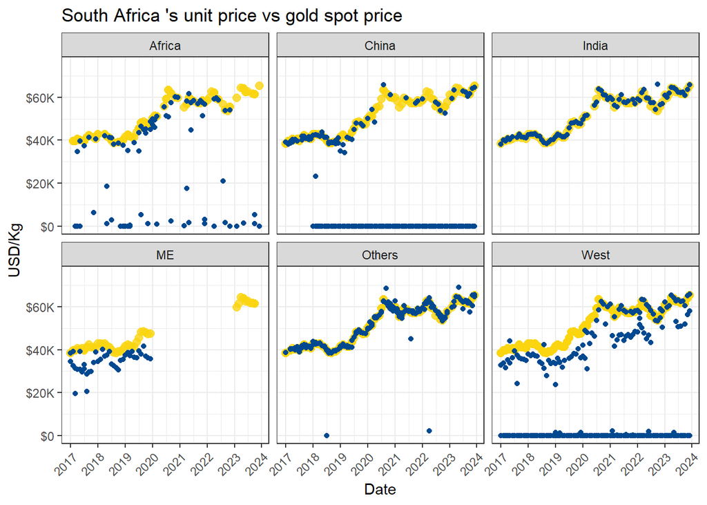

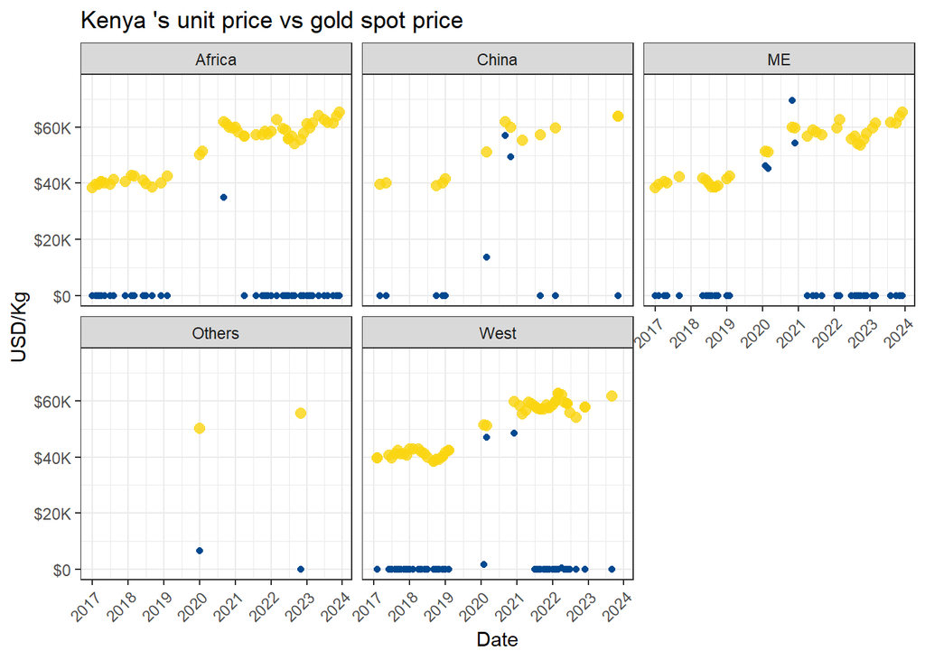

### Quantity Column Transformation and Correction

```r
temp <- data.frame(do.call(rbind, strsplit(as.character(df$unit_price), '\\.')))
temp$altQtyUnitAbbr <- df$altQtyUnitAbbr

# handle grams
#df[which(nchar(temp$X1) == 2),]
df[which(nchar(temp$X1) == 2 & temp$altQtyUnitAbbr == 'g'),]$altQty <-
  df[which(nchar(temp$X1) == 2 & temp$altQtyUnitAbbr == 'g'),]$altQty/1000
df[which(nchar(temp$X1) == 2 & temp$altQtyUnitAbbr == 'g'),]$unit_price <-
  df[which(nchar(temp$X1) == 2 & temp$altQtyUnitAbbr == 'g'),]$unit_price*1000

# handle milligrams
df[which(temp$X1 == '0' & substr(temp$X2, start = 1, stop = 1) == '0'),]$altQty <-
  df[which(temp$X1 == '0' & substr(temp$X2, start = 1, stop = 1) == '0'),]$altQty/1000000

df[which(temp$X1 == '0' & substr(temp$X2, start = 1, stop = 1) == '0'),]$unit_price <-
  df[which(temp$X1 == '0' & substr(temp$X2, start = 1, stop = 1) == '0'),]$unit_price*1000000

# convert grams to kg
#df[df$altQtyUnitAbbr == 'g',]$altQty <- df[df$altQtyUnitAbbr == 'g',]$altQty/1000
#df$unit_price <- df$primaryValue/df$altQty

# find the difference between gold spot price and unit price
df$gdiff <- df$gold_price - df$unit_price
```

```r
Reporter <- 'South Africa'
plot_stats = cmdcode_unitprice_plot(df, Reporter)
plot1 <- plot_stats[[1]]

Reporter <- 'Kenya'
plot_stats = cmdcode_unitprice_plot(df, Reporter)
plot2 <- plot_stats[[1]]
```

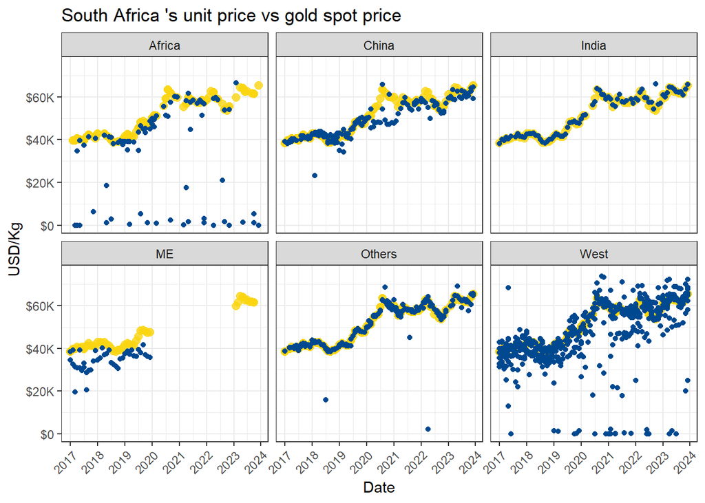

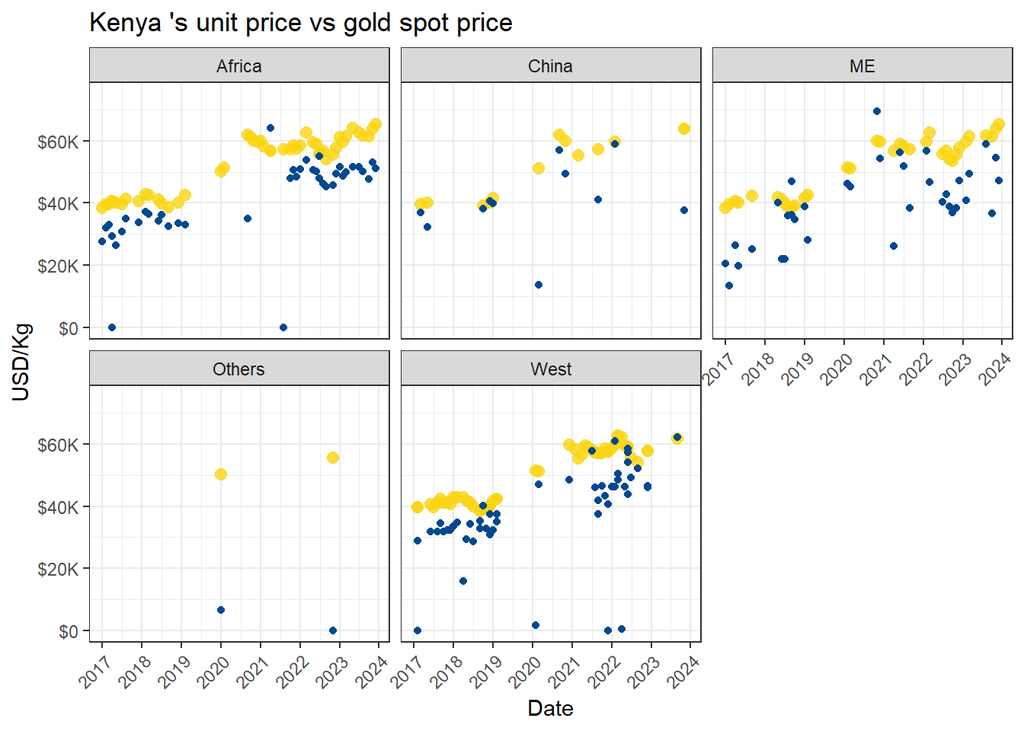

### Anova Test

```r
plot_df <- plot_stats[[2]]
ttestDF <- plot_df[plot_df$ctyGroup == 'West',] %>% select(unit_price, gold_price, date)
ttestDF <- ttestDF[ttestDF$unit_price > 10000 & ttestDF$unit_price < 70000,]
ttestDF <- ttestDF %>% group_by(date) %>%
  summarise(unit_price = mean(unit_price), gold_price = mean(gold_price))

expected <- ttestDF$gold_price
observed <- ttestDF$unit_price
time <- ttestDF$date

wide <- data.frame(expected, observed)
long <- cbind(time, stack(wide))

fm2 <- lm(values ~ ind/(time + 1) + 0, long)
fm1 <- lm(values ~ ind + time + 0, long)
anova(fm1, fm2)
```

```
Analysis of Variance Table

Model 1: values ~ ind + time + 0
Model 2: values ~ ind/(time + 1) + 0
  Res.Df        RSS Df Sum of Sq     F Pr(>F)
1     69 1194714898
2     68 1193539591  1   1175307 0.067 0.7966
```

`P-value > 0.05`

We ran a linear model with two slopes and and another with one slope. Both have two intercepts. Then compare them using anova. The slopes are not significantly different so we cannot reject the NULL hypothesis (the slopes are same).

We can also use the granger test to see if a time series model fit for gold spot price can be used for the unit price. This should indicate if the two trends are same.

### Gold Trade Graph

```r
plot_df <- df[df$reporterDesc == "Kenya" & df$cmdCode == 7108,]

plot_df <- plot_df %>% group_by(date) %>% summarise(sum = sum(primaryValue))

plot_df$gold_price <- NA

plot_df <- plot_df %>%
  complete(date = seq(date[1], date[nrow(plot_df)], by = "1 month"),
           fill = list(sum = 0, gold_price = 0))

plot_df$gold_price <- sapply(plot_df$date, function(x)
  gold_df[gold_df$date == x,]$priceUSD_troyounce)

yrng <- range(plot_df$sum)
xrng <- range(plot_df$date)
caption <- paste("Kenya Gold Exports\n", "    2017 - 2023")

from <- as.Date('2020-01-01')
to <- as.Date('2022-01-01')

shade <- data.frame(from, to)

breaks.vec <- seq(min(plot_df$date), max(plot_df$date), by = "6 month")
scaleVal <- 1/90
gpriceColor <- "#FAD510"

g <- ggplot(data = plot_df, aes(x = date, y = sum)) +
    geom_bar(stat = "identity", fill="#004990") +
    geom_point(aes(y = gold_price/scaleVal), size=2, color=gpriceColor) +
    geom_line(aes(y = gold_price/scaleVal), linewidth=1.5, color=gpriceColor) +
    scale_x_date(expand = c(0.01,0.01), breaks = breaks.vec, date_labels = "%b-%Y") +
    scale_y_continuous(expand = c(0,0), limits = c(0, 7000000), breaks = seq(0, 6000000, by = 1000000),
                       labels = scales::label_dollar(scale_cut = scales::cut_short_scale()),
                       sec.axis = sec_axis(~.*scaleVal, name="Gold Spot Price (USD/KG)",
                                           labels = scales::label_dollar(scale_cut =
                                                           scales::cut_short_scale()),
                                           breaks = c(30000,40000,50000,60000,70000))
                       ) +
    annotate(geom = "text", x = xrng[1], y = yrng[2], label = caption,
             hjust = 0, vjust = 1, size = 4) +
    theme_bw() +
    theme(axis.text.x = element_text(angle=45, hjust = 1),
          axis.title.y = element_text(color = '#004990', size = 13),
          axis.title.y.right = element_text(color = gpriceColor, size = 13)) +
    theme(panel.grid.minor.x = element_blank()) +
    theme(panel.grid.minor.y = element_blank()) +
    geom_rect(data = shade, inherit.aes=FALSE, aes(xmin = from, xmax = to, ymin = -Inf, ymax = Inf), color="transparent", fill="grey", alpha=0.3) +
    annotate(geom = "curve", x = as.Date('2022-02-01'), y = 6600000, xend = as.Date('2020-12-01'), yend = 6050000,
             curvature = .2, arrow = arrow(length = unit(2, "mm"))) +
    annotate(geom = "text", x = as.Date('2022-03-01'), y = 6600000,
             label = "COVID-19 Period", hjust = "left") +
    xlab("Date") + ylab("Gold Export Value (USD)")
    #theme(plot.background = element_rect(fill = "gray60"),plot.margin = margin(t = 0, r = 0, b = 0, l = 0, unit = "cm"))
```

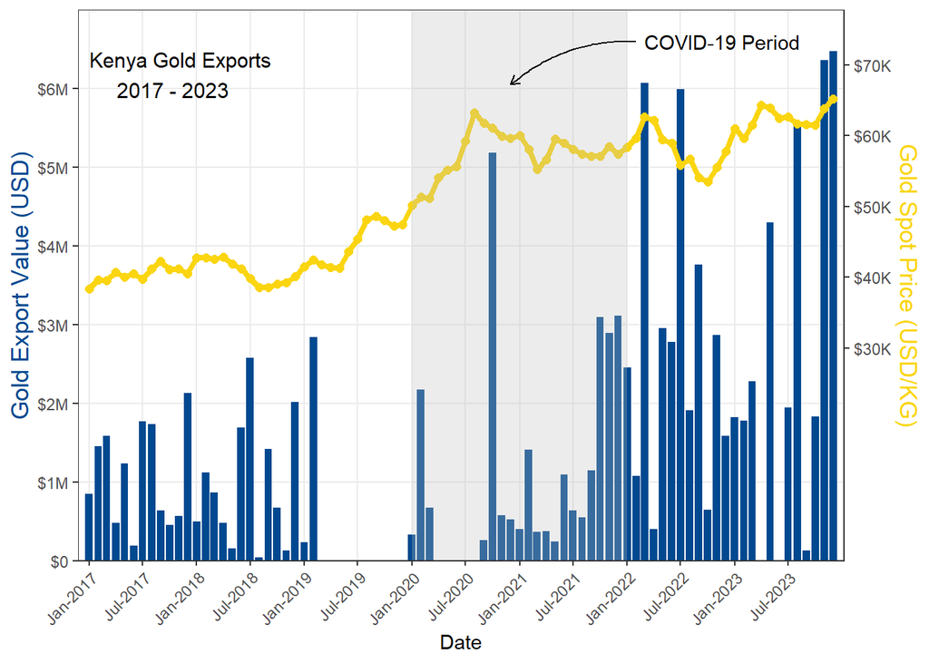

Figure 1: Trade value between 2017-2023

### Compare BRICS and West trade

```r
plot_grouped_bar <- function(country, plot_df){

  plot_df <- plot_df[plot_df$reporterDesc == country & plot_df$bricsflag %in% c('b', 'w') & plot_df$cmdCode == 7108,]
  plot_df <- plot_df %>% group_by(flow, bricsflag, date) %>% summarise(sum = sum(primaryValue))

  breaks.vec <- seq(min(plot_df$date), max(plot_df$date), by = "1 year")

  ggplot(plot_df, aes(date, sum, fill = bricsflag))+
    geom_bar(stat = "identity", position = position_dodge(preserve = "single"))+
    coord_cartesian(ylim = c(0,max(plot_df$sum))) +
    scale_y_continuous(labels = scales::label_dollar(scale_cut = scales::cut_short_scale()))+
    scale_x_date(breaks = breaks.vec, date_labels = "%Y") +
    ylab("Gold Export Value (USD)") + xlab("Date") +
    guides(fill = guide_legend(title = 'Country Group')) +
    scale_fill_manual(labels = c("BRICS", "West"), values = c("firebrick2", "#004990")) +
    labs(title = country) +
    theme_bw() +
    theme(axis.text.x = element_text(angle = 45, vjust = 1, hjust = 1)) +
    facet_grid( ~ flow)

}
```

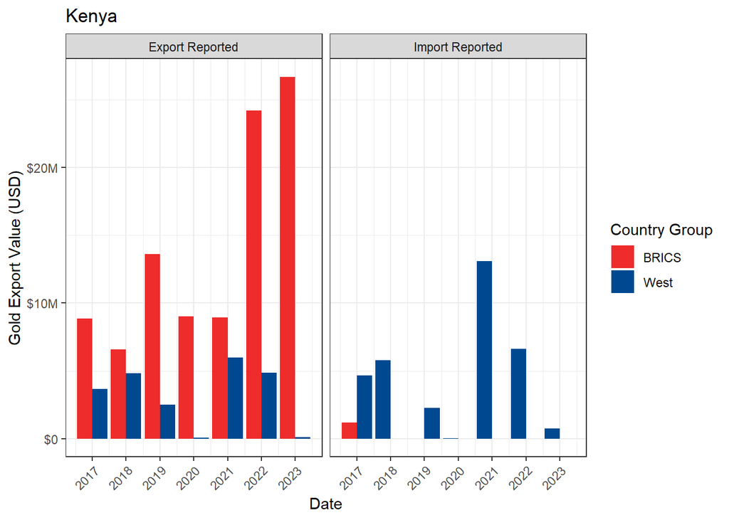

Figure 2: Comparison

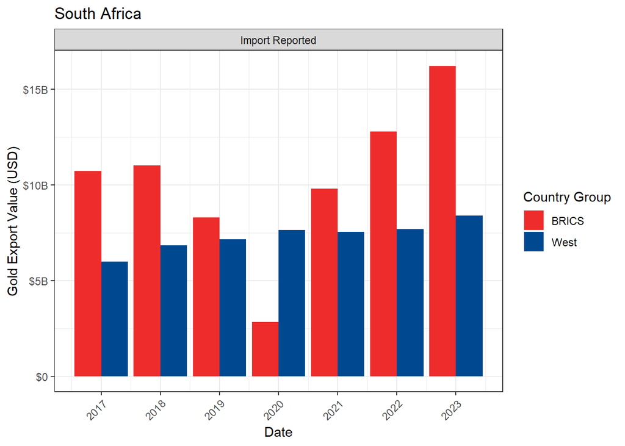

Figure 3: Comparison